```python
import pandas as pd
import matplotlib.pyplot as plt
import numpy as np
from scipy import stats
```

# Human Activity Recognition with Smartphones - Supervised Machine Learning

**Sarah Santos - Esteban O. Lopez**

This notebook aims at finding the optimal classifier for the problem of Human Activity Recognition. A problem in which the data obtained by messuring the movement and speed of a person performing different physical activities while wearing a device.

**Data**

The dataset used is found in kaggle: https://www.kaggle.com/datasets/uciml/human-activity-recognition-with-smartphones?datasetId=226 Related research: Davide Anguita, Alessandro Ghio, Luca Oneto, Xavier Parra and Jorge L. Reyes-Ortiz. A Public Domain Dataset for Human Activity Recognition Using Smartphones. 21st European Symposium on Artificial Neural Networks, Computational Intelligence and Machine Learning, ESANN 2013. Bruges, Belgium 24-26 April 2013

The dataset is composed of several variables all product of the observation of sensors in devices carried by people subject of an experiment. The attribute information according to the source, for each record in the dataset the following is provided:

- Triaxial acceleration from the accelerometer (total acceleration) and the estimated body acceleration.
- Triaxial Angular velocity from the gyroscope.
- A 561-feature vector with time and frequency domain variables.
- Its activity label.
- An identifier of the subject who carried out the experiment.

The data is already divided into train an test sets. The files are previously downloaded and saved in the "data" folder.

## Data Exploration

### Training set

```python
 df = pd.read_csv('data/train.csv') #read the data with pandas
```

```python
df.head()
```

|  | tBodyAcc-mean()-X | tBodyAcc-mean()-Y | tBodyAcc-mean()-Z | tBodyAcc-std()-X | tBodyAcc-std()-Y | tBodyAcc-std()-Z | tBodyAcc-mad()-X | tBodyAcc-mad()-Y | tBodyAcc-mad()-Z | tBodyAcc-max()-X | ... | fBodyBodyGyroJerkMag-kurtosis() | angle(tBodyAccMean,gravity) | angle(tBodyAccJerkMean),gravityMean) | angle(tBodyGyroMean,gravityMean) | angle(tBodyGyroJerkMean,gravityMean) | angle(X,gravityMean) | angle(Y,gravityMean) | angle(Z,gravityMean) | subject | Activity |
| --- | --- | --- | --- | --- | --- | --- | --- | --- | --- | --- | --- | --- | --- | --- | --- | --- | --- | --- | --- | --- | --- |
| 0 | 0.288585 | -0.020294 | -0.132905 | -0.995279 | -0.983111 | -0.913526 | -0.995112 | -0.983185 | -0.923527 | -0.934724 | ... | -0.710304 | -0.112754 | 0.030400 | -0.464761 | -0.018446 | -0.841247 | 0.179941 | -0.058627 | 1 | STANDING |
| 1 | 0.278419 | -0.016411 | -0.123520 | -0.998245 | -0.975300 | -0.960322 | -0.998807 | -0.974914 | -0.957686 | -0.943068 | ... | -0.861499 | 0.053477 | -0.007435 | -0.732626 | 0.703511 | -0.844788 | 0.180289 | -0.054317 | 1 | STANDING |
| 2 | 0.279653 | -0.019467 | -0.113462 | -0.995380 | -0.967187 | -0.978944 | -0.996520 | -0.963668 | -0.977469 | -0.938692 | ... | -0.760104 | -0.118559 | 0.177899 | 0.100699 | 0.808529 | -0.848933 | 0.180637 | -0.049118 | 1 | STANDING |
| 3 | 0.279174 | -0.026201 | -0.123283 | -0.996091 | -0.983403 | -0.990675 | -0.997099 | -0.982750 | -0.989302 | -0.938692 | ... | -0.482845 | -0.036788 | -0.012892 | 0.640011 | -0.485366 | -0.848649 | 0.181935 | -0.047663 | 1 | STANDING |
| 4 | 0.276629 | -0.016570 | -0.115362 | -0.998139 | -0.980817 | -0.990482 | -0.998321 | -0.979672 | -0.990441 | -0.942469 | ... | -0.699205 | 0.123320 | 0.122542 | 0.693578 | -0.615971 | -0.847865 | 0.185151 | -0.043892 | 1 | STANDING |

5 rows × 563 columns

- First some basic information about the object, shape and types of variables

```python
df.info() #display the information about the object
```

```
<class 'pandas.core.frame.DataFrame'>
RangeIndex: 7352 entries, 0 to 7351
Columns: 563 entries, tBodyAcc-mean()-X to Activity
dtypes: float64(561), int64(1), object(1)
memory usage: 31.6+ MB
```

```python
print(f"The shape of the dataframe: {df.shape}.")
```

```
The shape of the dataframe: (7352, 563).
```

```python
df.columns
```

```
Index(['tBodyAcc-mean()-X', 'tBodyAcc-mean()-Y', 'tBodyAcc-mean()-Z',
       'tBodyAcc-std()-X', 'tBodyAcc-std()-Y', 'tBodyAcc-std()-Z',
       'tBodyAcc-mad()-X', 'tBodyAcc-mad()-Y', 'tBodyAcc-mad()-Z',
       'tBodyAcc-max()-X',
       ...
       'fBodyBodyGyroJerkMag-kurtosis()', 'angle(tBodyAccMean,gravity)',
       'angle(tBodyAccJerkMean),gravityMean)',
       'angle(tBodyGyroMean,gravityMean)',
       'angle(tBodyGyroJerkMean,gravityMean)', 'angle(X,gravityMean)',
       'angle(Y,gravityMean)', 'angle(Z,gravityMean)', 'subject', 'Activity'],
      dtype='object', length=563)
```

```python
df.dtypes
```

```
tBodyAcc-mean()-X       float64
tBodyAcc-mean()-Y       float64
tBodyAcc-mean()-Z       float64
tBodyAcc-std()-X        float64
tBodyAcc-std()-Y        float64
                         ...
angle(X,gravityMean)    float64
angle(Y,gravityMean)    float64
angle(Z,gravityMean)    float64
subject                   int64
Activity                 object
Length: 563, dtype: object
```

```python
df.dtypes.value_counts()
```

```
float64    561
int64        1
object       1
dtype: int64
```

- Among the columns, we find 561 numeric features, the categorical label of the activity performed and the identifier of the subject performing the activity.
- For this exercise the subject is not going to be relevant for the analysis. So it will be later eliminated from the dataframe
- We will check the ocurrences by class in the data:

```
Value counts for the target variable:
LAYING                1407
STANDING              1374
SITTING               1286
WALKING               1226
WALKING_UPSTAIRS      1073
WALKING_DOWNSTAIRS     986
Name: Activity, dtype: int64
```

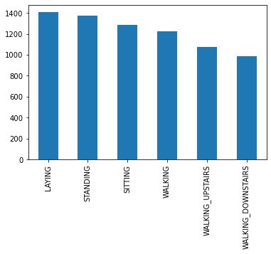

```python
print("Value counts for the target variable:")
print(df['Activity'].value_counts())
df['Activity'].value_counts().plot(kind='bar')
```

- Even though some classes have more observation tha others, does not really seem to be an unbalanced dataset, for which balancing will not be performed.
- A new variable will be created to transform the categorical values of the target into numeric ones.
- Now a basic statistical description of the features:

```python
statistics = df.iloc[:,:-2].describe() #create a dataframe that holds the statistical description without the activity or the subject variables
```

```python
statistics
```

|  | tBodyAcc-mean()-X | tBodyAcc-mean()-Y | tBodyAcc-mean()-Z | tBodyAcc-std()-X | tBodyAcc-std()-Y | tBodyAcc-std()-Z | tBodyAcc-mad()-X | tBodyAcc-mad()-Y | tBodyAcc-mad()-Z | tBodyAcc-max()-X | ... | fBodyBodyGyroJerkMag-meanFreq() | fBodyBodyGyroJerkMag-skewness() | fBodyBodyGyroJerkMag-kurtosis() | angle(tBodyAccMean,gravity) | angle(tBodyAccJerkMean),gravityMean) | angle(tBodyGyroMean,gravityMean) | angle(tBodyGyroJerkMean,gravityMean) | angle(X,gravityMean) | angle(Y,gravityMean) | angle(Z,gravityMean) |
| --- | --- | --- | --- | --- | --- | --- | --- | --- | --- | --- | --- | --- | --- | --- | --- | --- | --- | --- | --- | --- | --- |
| count | 7352.000000 | 7352.000000 | 7352.000000 | 7352.000000 | 7352.000000 | 7352.000000 | 7352.000000 | 7352.000000 | 7352.000000 | 7352.000000 | ... | 7352.000000 | 7352.000000 | 7352.000000 | 7352.000000 | 7352.000000 | 7352.000000 | 7352.000000 | 7352.000000 | 7352.000000 | 7352.000000 |
| mean | 0.274488 | -0.017695 | -0.109141 | -0.605438 | -0.510938 | -0.604754 | -0.630512 | -0.526907 | -0.606150 | -0.468604 | ... | 0.125293 | -0.307009 | -0.625294 | 0.008684 | 0.002186 | 0.008726 | -0.005981 | -0.489547 | 0.058593 | -0.056515 |
| std | 0.070261 | 0.040811 | 0.056635 | 0.448734 | 0.502645 | 0.418687 | 0.424073 | 0.485942 | 0.414122 | 0.544547 | ... | 0.250994 | 0.321011 | 0.307584 | 0.336787 | 0.448306 | 0.608303 | 0.477975 | 0.511807 | 0.297480 | 0.279122 |
| min | -1.000000 | -1.000000 | -1.000000 | -1.000000 | -0.999873 | -1.000000 | -1.000000 | -1.000000 | -1.000000 | -1.000000 | ... | -1.000000 | -0.995357 | -0.999765 | -0.976580 | -1.000000 | -1.000000 | -1.000000 | -1.000000 | -1.000000 | -1.000000 |
| 25% | 0.262975 | -0.024863 | -0.120993 | -0.992754 | -0.978129 | -0.980233 | -0.993591 | -0.978162 | -0.980251 | -0.936219 | ... | -0.023692 | -0.542602 | -0.845573 | -0.121527 | -0.289549 | -0.482273 | -0.376341 | -0.812065 | -0.017885 | -0.143414 |
| 50% | 0.277193 | -0.017219 | -0.108676 | -0.946196 | -0.851897 | -0.859365 | -0.950709 | -0.857328 | -0.857143 | -0.881637 | ... | 0.134000 | -0.343685 | -0.711692 | 0.009509 | 0.008943 | 0.008735 | -0.000368 | -0.709417 | 0.182071 | 0.003181 |
| 75% | 0.288461 | -0.010783 | -0.097794 | -0.242813 | -0.034231 | -0.262415 | -0.292680 | -0.066701 | -0.265671 | -0.017129 | ... | 0.289096 | -0.126979 | -0.503878 | 0.150865 | 0.292861 | 0.506187 | 0.359368 | -0.509079 | 0.248353 | 0.107659 |
| max | 1.000000 | 1.000000 | 1.000000 | 1.000000 | 0.916238 | 1.000000 | 1.000000 | 0.967664 | 1.000000 | 1.000000 | ... | 0.946700 | 0.989538 | 0.956845 | 1.000000 | 1.000000 | 0.998702 | 0.996078 | 1.000000 | 0.478157 | 1.000000 |

8 rows × 561 columns

- It is difficutl to observe with detail at all the variables at the same time. However we can notice that mostly the observations in each variable are in the range [-1,1], we can test this hypothesis by estimating the minimum across all minimum variables and the maximum among all maximum variables:

```python
mins = statistics.min(axis=1)
maxs = statistics.max(axis=1)
print('Minimum value in each row : ')
print(mins)
print('\nMaximum value in each row : ')
print(maxs)
```

```
Minimum value in each row :
count    7352.000000
mean       -0.984059
std         0.040811
min        -1.000000
25%        -1.000000
50%        -1.000000
75%        -0.991362
max         0.465197
dtype: float64

Maximum value in each row :
count    7352.000000
mean        0.830434
std         0.751733
min        -0.493874
25%         0.804863
50%         0.963906
75%         0.994417
max         1.000000
dtype: float64
```

- We can see that all values are bounded in between -1 and 1. Meaning that the data can be thought of a multidimentional sphere of radius 1. For this, standarization will not be necessary for the dataset.
- Now, we focus in finding if there is any null or NA observation across the frame.

```python
print(df.isnull().sum())
print(f"\nThe total number of null observations across the data set is: {sum(list(df.isnull().sum()))}")
```

```
tBodyAcc-mean()-X       0
tBodyAcc-mean()-Y       0
tBodyAcc-mean()-Z       0
tBodyAcc-std()-X        0
tBodyAcc-std()-Y        0
                       ..
angle(X,gravityMean)    0
angle(Y,gravityMean)    0
angle(Z,gravityMean)    0
subject                 0
Activity                0
Length: 563, dtype: int64

The total number of null observations across the data set is: 0
```

```python
print(df.isna().sum())
print(f"\nThe total number of NA observations across the data set is: {sum(list(df.isna().sum()))}")
```

```
tBodyAcc-mean()-X       0
tBodyAcc-mean()-Y       0
tBodyAcc-mean()-Z       0
tBodyAcc-std()-X        0
tBodyAcc-std()-Y        0
                       ..
angle(X,gravityMean)    0
angle(Y,gravityMean)    0
angle(Z,gravityMean)    0
subject                 0
Activity                0
Length: 563, dtype: int64

The total number of NA observations across the data set is: 0
```

- There is not null or NA values in the data. For this, there is no need for removing or replacing observations.
- Now we check the correlations among all the features:

```python
correlation = df.drop(["subject","Activity"], axis = 1).corr()
correlation.head() #the correlation matrix is hard to interpret with so many variables.
```

|  | tBodyAcc-mean()-X | tBodyAcc-mean()-Y | tBodyAcc-mean()-Z | tBodyAcc-std()-X | tBodyAcc-std()-Y | tBodyAcc-std()-Z | tBodyAcc-mad()-X | tBodyAcc-mad()-Y | tBodyAcc-mad()-Z | tBodyAcc-max()-X | ... | fBodyBodyGyroJerkMag-meanFreq() | fBodyBodyGyroJerkMag-skewness() | fBodyBodyGyroJerkMag-kurtosis() | angle(tBodyAccMean,gravity) | angle(tBodyAccJerkMean),gravityMean) | angle(tBodyGyroMean,gravityMean) | angle(tBodyGyroJerkMean,gravityMean) | angle(X,gravityMean) | angle(Y,gravityMean) | angle(Z,gravityMean) |
| --- | --- | --- | --- | --- | --- | --- | --- | --- | --- | --- | --- | --- | --- | --- | --- | --- | --- | --- | --- | --- | --- |
| tBodyAcc-mean()-X | 1.000000 | 0.148061 | -0.256952 | 0.000619 | -0.021903 | -0.044617 | 0.006290 | -0.022754 | -0.047558 | 0.044062 | ... | 0.030681 | -0.017557 | -0.015613 | -0.544320 | 0.012173 | 0.037444 | 0.028844 | -0.035257 | 0.034371 | 0.028242 |
| tBodyAcc-mean()-Y | 0.148061 | 1.000000 | -0.078769 | -0.045160 | -0.044920 | -0.049746 | -0.044180 | -0.045049 | -0.050402 | -0.038108 | ... | -0.022395 | -0.001587 | -0.004459 | 0.070559 | -0.013541 | 0.017967 | 0.075679 | -0.005309 | 0.001053 | -0.013903 |
| tBodyAcc-mean()-Z | -0.256952 | -0.078769 | 1.000000 | -0.020217 | -0.016641 | -0.008410 | -0.018747 | -0.015203 | -0.001988 | -0.037197 | ... | -0.020481 | 0.020091 | 0.019127 | 0.052841 | -0.039836 | -0.063609 | -0.034037 | 0.008587 | -0.015288 | -0.022643 |
| tBodyAcc-std()-X | 0.000619 | -0.045160 | -0.020217 | 1.000000 | 0.927461 | 0.851668 | 0.998632 | 0.920888 | 0.846392 | 0.980844 | ... | -0.065987 | 0.148034 | 0.115565 | -0.035011 | -0.021633 | 0.018985 | -0.024810 | -0.371653 | 0.471065 | 0.394825 |
| tBodyAcc-std()-Y | -0.021903 | -0.044920 | -0.016641 | 0.927461 | 1.000000 | 0.895510 | 0.922803 | 0.997347 | 0.894509 | 0.917366 | ... | -0.105621 | 0.206227 | 0.176946 | -0.020379 | -0.012505 | -0.008507 | -0.014592 | -0.380531 | 0.523600 | 0.433169 |

5 rows × 561 columns

- A correlation plot can make it easier to get an idea about the relationship among the variables

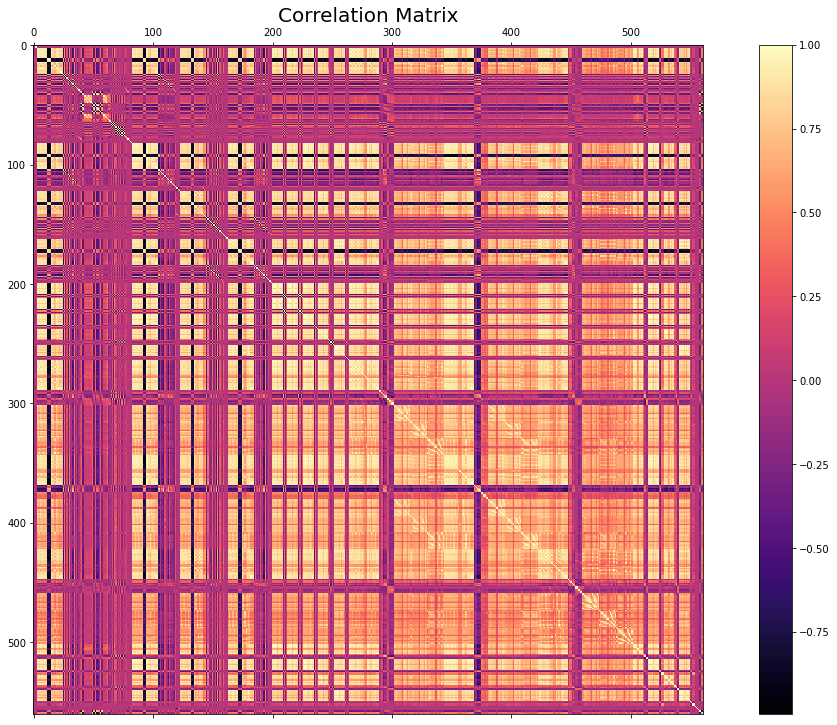

```python
import matplotlib.pyplot as plt

correlation = correlation.to_numpy()

f = plt.figure(figsize=(20, 12))
plt.matshow(correlation, fignum=f.number,cmap='magma')
cb = plt.colorbar()
cb.ax.tick_params(labelsize=10)
plt.title('Correlation Matrix', fontsize=20)
```

- From the previous plot it can be seen that some variables are highly correlated to each other, both positive and negative correlations are present.
- Given the size of the data and the fact that the features are so correlated, a strategy to reduce the number of features will be implemented. So that the model will be easier to compute.

### Test set

```python
df_test = pd.read_csv('data/test.csv')
```

```python
df_test.head()
```

|  | tBodyAcc-mean()-X | tBodyAcc-mean()-Y | tBodyAcc-mean()-Z | tBodyAcc-std()-X | tBodyAcc-std()-Y | tBodyAcc-std()-Z | tBodyAcc-mad()-X | tBodyAcc-mad()-Y | tBodyAcc-mad()-Z | tBodyAcc-max()-X | ... | fBodyBodyGyroJerkMag-kurtosis() | angle(tBodyAccMean,gravity) | angle(tBodyAccJerkMean),gravityMean) | angle(tBodyGyroMean,gravityMean) | angle(tBodyGyroJerkMean,gravityMean) | angle(X,gravityMean) | angle(Y,gravityMean) | angle(Z,gravityMean) | subject | Activity |
| --- | --- | --- | --- | --- | --- | --- | --- | --- | --- | --- | --- | --- | --- | --- | --- | --- | --- | --- | --- | --- | --- |
| 0 | 0.257178 | -0.023285 | -0.014654 | -0.938404 | -0.920091 | -0.667683 | -0.952501 | -0.925249 | -0.674302 | -0.894088 | ... | -0.705974 | 0.006462 | 0.162920 | -0.825886 | 0.271151 | -0.720009 | 0.276801 | -0.057978 | 2 | STANDING |
| 1 | 0.286027 | -0.013163 | -0.119083 | -0.975415 | -0.967458 | -0.944958 | -0.986799 | -0.968401 | -0.945823 | -0.894088 | ... | -0.594944 | -0.083495 | 0.017500 | -0.434375 | 0.920593 | -0.698091 | 0.281343 | -0.083898 | 2 | STANDING |
| 2 | 0.275485 | -0.026050 | -0.118152 | -0.993819 | -0.969926 | -0.962748 | -0.994403 | -0.970735 | -0.963483 | -0.939260 | ... | -0.640736 | -0.034956 | 0.202302 | 0.064103 | 0.145068 | -0.702771 | 0.280083 | -0.079346 | 2 | STANDING |
| 3 | 0.270298 | -0.032614 | -0.117520 | -0.994743 | -0.973268 | -0.967091 | -0.995274 | -0.974471 | -0.968897 | -0.938610 | ... | -0.736124 | -0.017067 | 0.154438 | 0.340134 | 0.296407 | -0.698954 | 0.284114 | -0.077108 | 2 | STANDING |
| 4 | 0.274833 | -0.027848 | -0.129527 | -0.993852 | -0.967445 | -0.978295 | -0.994111 | -0.965953 | -0.977346 | -0.938610 | ... | -0.846595 | -0.002223 | -0.040046 | 0.736715 | -0.118545 | -0.692245 | 0.290722 | -0.073857 | 2 | STANDING |

5 rows × 563 columns

- Information of the variables in the test set:

```python
df_test.info() #display the information about the object
```

```
<class 'pandas.core.frame.DataFrame'>
RangeIndex: 2947 entries, 0 to 2946
Columns: 563 entries, tBodyAcc-mean()-X to Activity
dtypes: float64(561), int64(1), object(1)
memory usage: 12.7+ MB
```

```python
print(f"The shape of the dataframe: {df_test.shape}.")
```

```
The shape of the dataframe: (2947, 563).
```

```python
df_test.columns
```

```
Index(['tBodyAcc-mean()-X', 'tBodyAcc-mean()-Y', 'tBodyAcc-mean()-Z',
       'tBodyAcc-std()-X', 'tBodyAcc-std()-Y', 'tBodyAcc-std()-Z',
       'tBodyAcc-mad()-X', 'tBodyAcc-mad()-Y', 'tBodyAcc-mad()-Z',
       'tBodyAcc-max()-X',
       ...
       'fBodyBodyGyroJerkMag-kurtosis()', 'angle(tBodyAccMean,gravity)',
       'angle(tBodyAccJerkMean),gravityMean)',
       'angle(tBodyGyroMean,gravityMean)',
       'angle(tBodyGyroJerkMean,gravityMean)', 'angle(X,gravityMean)',
       'angle(Y,gravityMean)', 'angle(Z,gravityMean)', 'subject', 'Activity'],
      dtype='object', length=563)
```

```python
df_test.dtypes
```

```
tBodyAcc-mean()-X       float64
tBodyAcc-mean()-Y       float64
tBodyAcc-mean()-Z       float64
tBodyAcc-std()-X        float64
tBodyAcc-std()-Y        float64
                         ...
angle(X,gravityMean)    float64
angle(Y,gravityMean)    float64
angle(Z,gravityMean)    float64
subject                   int64
Activity                 object
Length: 563, dtype: object
```

```python
df_test.dtypes.value_counts()
```

```
float64    561
int64        1
object       1
dtype: int64
```

- Distribution of the classes in the test set:

```
Value counts for the target variable:
LAYING                537
STANDING              532
WALKING               496
SITTING               491
WALKING_UPSTAIRS      471
WALKING_DOWNSTAIRS    420
Name: Activity, dtype: int64
```

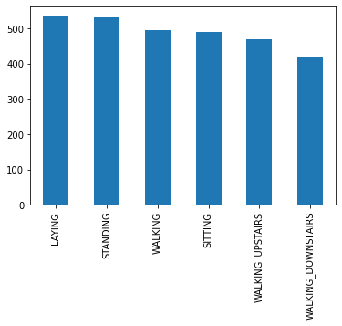

```python
print("Value counts for the target variable:")
print(df_test['Activity'].value_counts())
df_test['Activity'].value_counts().plot(kind='bar')
```

- Basic statistics for the test set:

```python
statistics = df_test.iloc[:,:-2].describe() #create a dataframe that holds the statistical description without the activity or the subject variables
```

```python
statistics
```

|  | tBodyAcc-mean()-X | tBodyAcc-mean()-Y | tBodyAcc-mean()-Z | tBodyAcc-std()-X | tBodyAcc-std()-Y | tBodyAcc-std()-Z | tBodyAcc-mad()-X | tBodyAcc-mad()-Y | tBodyAcc-mad()-Z | tBodyAcc-max()-X | ... | fBodyBodyGyroJerkMag-meanFreq() | fBodyBodyGyroJerkMag-skewness() | fBodyBodyGyroJerkMag-kurtosis() | angle(tBodyAccMean,gravity) | angle(tBodyAccJerkMean),gravityMean) | angle(tBodyGyroMean,gravityMean) | angle(tBodyGyroJerkMean,gravityMean) | angle(X,gravityMean) | angle(Y,gravityMean) | angle(Z,gravityMean) |
| --- | --- | --- | --- | --- | --- | --- | --- | --- | --- | --- | --- | --- | --- | --- | --- | --- | --- | --- | --- | --- | --- |
| count | 2947.000000 | 2947.000000 | 2947.000000 | 2947.000000 | 2947.000000 | 2947.000000 | 2947.000000 | 2947.000000 | 2947.000000 | 2947.000000 | ... | 2947.000000 | 2947.000000 | 2947.000000 | 2947.000000 | 2947.000000 | 2947.000000 | 2947.000000 | 2947.000000 | 2947.000000 | 2947.000000 |
| mean | 0.273996 | -0.017863 | -0.108386 | -0.613635 | -0.508330 | -0.633797 | -0.641278 | -0.522676 | -0.637038 | -0.462063 | ... | 0.130236 | -0.277593 | -0.598756 | 0.005264 | 0.003799 | 0.040029 | -0.017298 | -0.513923 | 0.074886 | -0.048720 |
| std | 0.060570 | 0.025745 | 0.042747 | 0.412597 | 0.494269 | 0.362699 | 0.385199 | 0.479899 | 0.357753 | 0.523916 | ... | 0.231018 | 0.317245 | 0.311042 | 0.336147 | 0.445077 | 0.634989 | 0.501311 | 0.509205 | 0.324300 | 0.241467 |
| min | -0.592004 | -0.362884 | -0.576184 | -0.999606 | -1.000000 | -0.998955 | -0.999417 | -0.999914 | -0.998899 | -0.952357 | ... | -0.785543 | -1.000000 | -1.000000 | -1.000000 | -0.993402 | -0.998898 | -0.991096 | -0.984195 | -0.913704 | -0.949228 |
| 25% | 0.262075 | -0.024961 | -0.121162 | -0.990914 | -0.973664 | -0.976122 | -0.992333 | -0.974131 | -0.975352 | -0.934447 | ... | -0.008433 | -0.517494 | -0.829593 | -0.130541 | -0.282600 | -0.518924 | -0.428375 | -0.829722 | 0.022140 | -0.098485 |
| 50% | 0.277113 | -0.016967 | -0.108458 | -0.931214 | -0.790972 | -0.827534 | -0.937664 | -0.799907 | -0.817005 | -0.852659 | ... | 0.142676 | -0.311023 | -0.683672 | 0.005188 | 0.006767 | 0.047113 | -0.026726 | -0.729648 | 0.181563 | -0.010671 |
| 75% | 0.288097 | -0.010143 | -0.097123 | -0.267395 | -0.105919 | -0.311432 | -0.321719 | -0.133488 | -0.322771 | -0.009965 | ... | 0.288320 | -0.083559 | -0.458332 | 0.146200 | 0.288113 | 0.622151 | 0.394387 | -0.545939 | 0.260252 | 0.092373 |
| max | 0.671887 | 0.246106 | 0.494114 | 0.465299 | 1.000000 | 0.489703 | 0.439657 | 1.000000 | 0.427958 | 0.786436 | ... | 1.000000 | 1.000000 | 1.000000 | 0.998898 | 0.986347 | 1.000000 | 1.000000 | 0.833180 | 1.000000 | 0.973113 |

8 rows × 561 columns

```python
mins = statistics.min(axis=1)
maxs = statistics.max(axis=1)
print('Minimum value in each row : ')
print(mins)
print('\nMaximum value in each row : ')
print(maxs)
```

```
Minimum value in each row :
count    2947.000000
mean       -0.985771
std         0.025745
min        -1.000000
25%        -1.000000
50%        -1.000000
75%        -0.990785
max        -0.511666
dtype: float64

Maximum value in each row :
count    2947.000000
mean        0.829881
std         0.743145
min        -0.095046
25%         0.836787
50%         0.941689
75%         0.992494
max         1.000000
dtype: float64
```

- We can confirm that the structure of the features in the test data set is similar to the one in the training: all values in the range [-1,1].

## Data Processing 1: PCA

- A print_score function is set to compare results between train and test results of the different models

```python
from sklearn.metrics import accuracy_score, confusion_matrix, classification_report

def print_score(clf, X_train, y_train, X_test, y_test, train=True):
    if train:
        pred = clf.predict(X_train)
        clf_report = pd.DataFrame(classification_report(y_train, pred, output_dict=True))
        print("Train Result:\n================================================")
        print(f"Accuracy Score: {accuracy_score(y_train, pred) * 100:.2f}%")
        print("_______________________________________________")
        print(f"CLASSIFICATION REPORT:\n{clf_report}")
        print("_______________________________________________")
        print(f"Confusion Matrix: \n {confusion_matrix(y_train, pred)}\n")

    elif train==False:
        pred = clf.predict(X_test)
        clf_report = pd.DataFrame(classification_report(y_test, pred, output_dict=True))
        print("Test Result:\n================================================")
        print(f"Accuracy Score: {accuracy_score(y_test, pred) * 100:.2f}%")
        print("_______________________________________________")
        print(f"CLASSIFICATION REPORT:\n{clf_report}")
        print("_______________________________________________")
        print(f"Confusion Matrix: \n {confusion_matrix(y_test, pred)}\n")
```

- For both data sets the "subject" variable will be droped.

```python
df = df.drop("subject", axis = 1)
df_test = df_test.drop("subject", axis = 1)
```

- The numeric version of the target variable will be created:

```python
df['activity_num'] = df['Activity']
df['activity_num'].replace(['STANDING', 'WALKING_UPSTAIRS', 'WALKING_DOWNSTAIRS', 'SITTING','LAYING', 'WALKING'],
                        [0,1,2,3,4,5], inplace=True)

df_test['activity_num'] = df_test['Activity']
df_test['activity_num'].replace(['STANDING', 'WALKING_UPSTAIRS', 'WALKING_DOWNSTAIRS', 'SITTING','LAYING', 'WALKING'],
                        [0,1,2,3,4,5], inplace=True)
```

- **Principal Component Analysis** will be performed on the training data set. Given the high correlation among the many features, it will be convenient to use the principal components to fit the different classifiers. Docummentation: https://scikit-learn.org/stable/modules/generated/sklearn.decomposition.PCA.html#sklearn.decomposition.PCA.fit_transform

```python
from sklearn import decomposition

x = df.drop(["Activity","activity_num"], axis = 1) #the PCA will be performed only on the features

pca = decomposition.PCA()
pca.fit(x) #the PCA is fit on the training data
```

```
PCA()
```

```python
principal_components = pca.transform(x) # The PCA is used to transform the training data into the set of components
df_pca = pd.DataFrame(principal_components)
df_pca.head()
```

|  | 0 | 1 | 2 | 3 | 4 | 5 | 6 | 7 | 8 | 9 | ... | 551 | 552 | 553 | 554 | 555 | 556 | 557 | 558 | 559 | 560 |
| --- | --- | --- | --- | --- | --- | --- | --- | --- | --- | --- | --- | --- | --- | --- | --- | --- | --- | --- | --- | --- | --- |
| 0 | -5.520280 | -0.290278 | -1.529929 | 1.333242 | 1.425089 | -0.194708 | 0.577454 | 0.691490 | -1.222865 | -0.363414 | ... | -6.922643e-19 | -1.700183e-16 | -2.218851e-16 | 1.412575e-16 | 4.116624e-17 | -1.084985e-16 | 1.016770e-15 | 1.035027e-16 | -7.845644e-17 | -2.244708e-16 |
| 1 | -5.535350 | -0.082530 | -1.924804 | 0.671273 | 0.671260 | 0.735144 | -0.616908 | -0.771714 | -0.615496 | -0.895525 | ... | -1.439789e-17 | -6.865424e-18 | -2.583876e-16 | 2.069710e-17 | 4.682698e-17 | -5.366981e-16 | -3.527862e-16 | 1.061070e-16 | 1.242805e-16 | -1.441219e-16 |
| 2 | -5.474988 | 0.287387 | -2.144642 | 0.531806 | 0.207824 | -0.037772 | 0.057628 | 0.093917 | -0.063147 | -0.216898 | ... | -4.111373e-18 | 4.717459e-17 | -1.515091e-16 | 6.485891e-18 | 4.048619e-17 | -9.089547e-18 | 8.140425e-16 | -5.076688e-19 | 5.502098e-17 | -1.188501e-16 |
| 3 | -5.677232 | 0.897031 | -2.018220 | 0.157125 | 0.759085 | 1.079547 | -0.267805 | -0.731391 | 0.281296 | 0.466269 | ... | -1.661319e-16 | 6.553197e-18 | -1.747703e-16 | 3.465223e-17 | 6.703025e-18 | 9.641519e-17 | -2.983557e-16 | -3.199072e-16 | -1.140142e-16 | -6.524859e-17 |
| 4 | -5.748749 | 1.162952 | -2.139533 | 0.207823 | 0.473090 | 0.463035 | -0.152227 | -0.107509 | 0.289819 | 0.539206 | ... | -5.199952e-17 | 2.089456e-17 | -1.858470e-16 | 3.160710e-17 | -1.291358e-16 | -9.145193e-17 | -2.937485e-16 | 4.384183e-16 | 9.111358e-17 | -1.584097e-16 |

5 rows × 561 columns

- The transformation results in a dataframe with the same amount of variables, but from which we can select the ones that account for most of the variance across the dataset.

Selection of the components:

```python
variance = 0 # variance explained by the components
component = 0 #number of components
for i in pca.explained_variance_ratio_:
    variance = variance + i
    component = component + 1
    if variance > 0.90: # we will use the components required to explain 90% of the variance in the set. We could use more, but the gain in variance for each additional component might not be worth it
        print(f"We can see that {variance}% of the variance is explained by the first {component} components")
        break
```

```
We can see that 0.9009370881393086% of the variance is explained by the first 34 components
```

- Now we plot the variance explained by these components

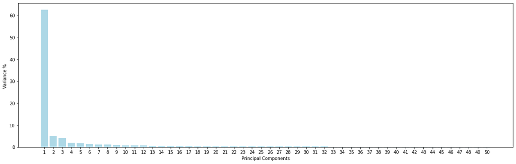

```python
PC = range(1, 51)

f = plt.figure(figsize=(20, 6))
plt.bar(PC,pca.explained_variance_ratio_[:50]*100, color = 'lightblue')
plt.xlabel('Principal Components')
plt.ylabel('Variance % ')
plt.xticks(PC)
plt.show()
```

- Given that the components are chosen, we proceed to create the train and test set transformed using the PCA object created and fit.

```python
x_train = df_pca.iloc[:, 0:34] #the x_train will be the set with the first 34 principal components
x_train = x_train.to_numpy()
y_train = df["activity_num"]
```

```python
x_test = pca.transform(df_test.drop(["Activity","activity_num"], axis = 1)) #x_test is the matrix of the first 34 principal components transformed from the test set
x_test = pd.DataFrame(x_test)
x_test = x_test.iloc[:, 0:34]
x_test = x_test.to_numpy()

y_test = df_test["activity_num"]
```

- With this step finished some cleaning in the environment might be done to keep resources for later use.

```python
whos
```

```
Variable                Type         Data/Info
----------------------------------------------
PC                      range        range(1, 51)
accuracy_score          function     <function accuracy_score at 0x0000026C00E564C0>
cb                      Colorbar     <matplotlib.colorbar.Colo<...>ct at 0x0000026C003C6F70>
classification_report   function     <function classification_<...>rt at 0x0000026C00E5A550>
component               int          34
confusion_matrix        function     <function confusion_matrix at 0x0000026C00E565E0>
correlation             ndarray      561x561: 314721 elems, type `float64`, 2517768 bytes (2.4011306762695312 Mb)
decomposition           module       <module 'sklearn.decompos<...>omposition\\__init__.py'>
df                      DataFrame          tBodyAcc-mean()-X  <...>[7352 rows x 563 columns]
df_pca                  DataFrame               0         1   <...>[7352 rows x 561 columns]
df_test                 DataFrame          tBodyAcc-mean()-X  <...>[2947 rows x 563 columns]
f                       Figure       Figure(1440x432)
i                       float64      0.002358658827543508
maxs                    Series       count    2947.000000\nmea<...> 1.000000\ndtype: float64
mins                    Series       count    2947.000000\nmea<...>-0.511666\ndtype: float64
np                      module       <module 'numpy' from 'C:\<...>ges\\numpy\\__init__.py'>
pca                     PCA          PCA()
pd                      module       <module 'pandas' from 'C:<...>es\\pandas\\__init__.py'>
plt                     module       <module 'matplotlib.pyplo<...>\\matplotlib\\pyplot.py'>
principal_components    ndarray      7352x561: 4124472 elems, type `float64`, 32995776 bytes (31.46722412109375 Mb)
print_score             function     <function print_score at 0x0000026C0599CE50>
statistics              DataFrame           tBodyAcc-mean()-X <...>n\n[8 rows x 561 columns]
stats                   module       <module 'scipy.stats' fro<...>ipy\\stats\\__init__.py'>
variance                float64      0.9009370881393086
x                       DataFrame          tBodyAcc-mean()-X  <...>[7352 rows x 561 columns]
x_test                  ndarray      2947x34: 100198 elems, type `float64`, 801584 bytes (782.796875 kb)
x_train                 ndarray      7352x34: 249968 elems, type `float64`, 1999744 bytes (1.9071044921875 Mb)
y_test                  Series       0       0\n1       0\n2  <...>ength: 2947, dtype: int64
y_train                 Series       0       0\n1       0\n2  <...>ength: 7352, dtype: int64
```

```python
del cb, correlation, f, maxs, mins, statistics,  PC, component, i, principal_components, variance, x, df_pca
```

```python
whos
```

```
Variable                Type         Data/Info
----------------------------------------------
accuracy_score          function     <function accuracy_score at 0x0000026C00E564C0>
classification_report   function     <function classification_<...>rt at 0x0000026C00E5A550>
confusion_matrix        function     <function confusion_matrix at 0x0000026C00E565E0>
decomposition           module       <module 'sklearn.decompos<...>omposition\\__init__.py'>
df                      DataFrame          tBodyAcc-mean()-X  <...>[7352 rows x 563 columns]
df_test                 DataFrame          tBodyAcc-mean()-X  <...>[2947 rows x 563 columns]
np                      module       <module 'numpy' from 'C:\<...>ges\\numpy\\__init__.py'>
pca                     PCA          PCA()
pd                      module       <module 'pandas' from 'C:<...>es\\pandas\\__init__.py'>
plt                     module       <module 'matplotlib.pyplo<...>\\matplotlib\\pyplot.py'>
print_score             function     <function print_score at 0x0000026C0599CE50>
stats                   module       <module 'scipy.stats' fro<...>ipy\\stats\\__init__.py'>
x_test                  ndarray      2947x34: 100198 elems, type `float64`, 801584 bytes (782.796875 kb)
x_train                 ndarray      7352x34: 249968 elems, type `float64`, 1999744 bytes (1.9071044921875 Mb)
y_test                  Series       0       0\n1       0\n2  <...>ength: 2947, dtype: int64
y_train                 Series       0       0\n1       0\n2  <...>ength: 7352, dtype: int64
```

## Data Modeling 1

- On the next part of the process different classification algorithms are performed to find the most appropriate classifier for this problem.
- The algorithms will be trained on the training set previously defined. The algorithms performed use cross validation on the training set to optimze the hyperparameters of the models.
- The test set previously defined is therefore used as a "validation" set. For this, the selection of the algorithm will be based on the performance on the test set.
- Since we have considered data is not too unbalanced and that there is not specific cost for missclassification, the scoring for all models will be the estimated accuracy of the model on the test set.
- All the models selected are from the sklearn package, except for the XGBoost model, which has its own library.

### 1. Logistic Regression

- A multinomial logistic regresion is fit.
- Docummentation on the logistic regression class: https://scikit-learn.org/stable/modules/generated/sklearn.linear_model.LogisticRegression.html
- Optimization of the model is achieved by GridSearchCV. This package allows to estimate a series of models using a combination of different sets of parameters. The best model will be selected according to the performance on cross validation. Docummentation: https://scikit-learn.org/stable/modules/generated/sklearn.model_selection.GridSearchCV.html

```python
from sklearn.model_selection import GridSearchCV
from sklearn.linear_model import LogisticRegression

#creating a set of parameters to be tried by
params = {"penalty": ["l2", None],
          "C": np.logspace(-4, 4, 20),
          "class_weight" :["balanced", None], #different possibilites accounting for inbalancing problems
          "solver": ["sag", "saga"]} #algorithms that work for multiclass problems

#the instance of the classifier is defined
lr_clf = LogisticRegression(multi_class='multinomial')

#the indstance of the crossvalidation grid search is defined
lr_cv = GridSearchCV(lr_clf, params, scoring="accuracy", n_jobs=-1, verbose=0, cv=5) #the classifier is used, in the grid of parameters defined, score is accuracy and 5 folds are created for cross validation
lr_cv.fit(x_train, y_train)
best_params = lr_cv.best_params_

print(f"Best parameters: {best_params}")
```

```
Best parameters: {'C': 0.615848211066026, 'class_weight': None, 'penalty': 'l2', 'solver': 'sag'}
```

Now we fit the model using the best parameters found:

```python
#the classifier is the re defined using the optimal parameters
lr_clf = LogisticRegression(**best_params)
lr_clf.fit(x_train, y_train)

#the results are shown
print_score(lr_clf, x_train, y_train, x_test, y_test, train=True)
print_score(lr_clf, x_train, y_train, x_test, y_test, train=False)
```

```
Train Result:
================================================
Accuracy Score: 94.91%
_______________________________________________
CLASSIFICATION REPORT:
                     0            1           2            3            4  \
precision     0.882941     0.974907    0.978550     0.891010     0.999290
recall        0.900291     0.977633    0.971602     0.870918     1.000000
f1-score      0.891532     0.976268    0.975064     0.880849     0.999645
support    1374.000000  1073.000000  986.000000  1286.000000  1407.000000

                     5  accuracy    macro avg  weighted avg
precision     0.980504  0.949129     0.951200      0.949133
recall        0.984502  0.949129     0.950824      0.949129
f1-score      0.982499  0.949129     0.950976      0.949093
support    1226.000000  0.949129  7352.000000   7352.000000
_______________________________________________
Confusion Matrix:
 [[1237    0    0  137    0    0]
 [   0 1049   11    0    0   13]
 [   0   17  958    0    0   11]
 [ 164    1    0 1120    1    0]
 [   0    0    0    0 1407    0]
 [   0    9   10    0    0 1207]]

Test Result:
================================================
Accuracy Score: 91.48%
_______________________________________________
CLASSIFICATION REPORT:
                    0           1           2           3           4  \
precision    0.872531    0.880086    0.947917    0.900648    0.998141
recall       0.913534    0.872611    0.866667    0.849287    1.000000
f1-score     0.892562    0.876333    0.905473    0.874214    0.999070
support    532.000000  471.000000  420.000000  491.000000  537.000000

                    5  accuracy    macro avg  weighted avg
precision    0.894052  0.914829     0.915562      0.915678
recall       0.969758  0.914829     0.911976      0.914829
f1-score     0.930368  0.914829     0.913003      0.914522
support    496.000000  0.914829  2947.000000   2947.000000
_______________________________________________
Confusion Matrix:
 [[486   0   0  46   0   0]
 [  0 411  12   0   0  48]
 [  0  47 364   0   0   9]
 [ 71   2   0 417   1   0]
 [  0   0   0   0 537   0]
 [  0   7   8   0   0 481]]
```

```python
# Creating the dataframe to store the different resutls

test_score = accuracy_score(y_test, lr_clf.predict(x_test)) * 100
train_score = accuracy_score(y_train, lr_clf.predict(x_train)) * 100

tuning_results_df = pd.DataFrame(data=[["Logistic Regression", train_score, test_score]],
                          columns=['Model', 'Training Accuracy %', 'Testing Accuracy %'])
tuning_results_df
```

|  | Model | Training Accuracy % | Testing Accuracy % |
| --- | --- | --- | --- |
| 0 | Tuned Logistic Regression | 94.912949 | 91.482864 |

### 2. K-nearest neighbors

```python
from sklearn.neighbors import KNeighborsClassifier
```

- We create 2 different list, train and test score list which are empty at first
- Fit the k-nearest neighbors classifier from the training dataset
- For each K the accuracy score of train and test is append to the list score

```python
train_score = []
test_score = []
neighbors = range(1, 31)

for k in neighbors:
    model = KNeighborsClassifier(n_neighbors=k)
    model.fit(x_train, y_train)
    train_score.append(accuracy_score(y_train, model.predict(x_train)))
    test_score.append(accuracy_score(y_test, model.predict(x_test)))
```

- We will be plotting the relationship between the values of K and the corresponding testing accuracy. It will be done using matplotlib library.

```
Maximum KNN score on the test data: 100.00
```

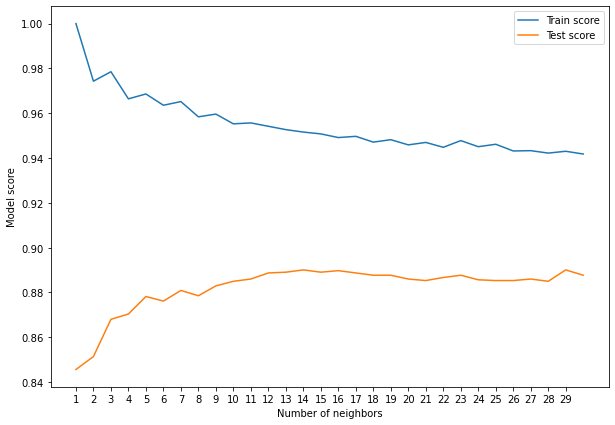

```python
plt.figure(figsize=(10, 7))
plt.plot(neighbors, train_score, label="Train score")
plt.plot(neighbors, test_score, label="Test score")
plt.xticks(np.arange(1, 30, 1))
plt.xlabel("Number of neighbors")
plt.ylabel("Model score")
plt.legend()

print(f"Maximum KNN score on the test data: {max(train_score)*100:.2f}")
```

- The last 2 values on the score for the testing set are high but in the train score are too low. For that we choose a maximum on the accuracy found for the test, excluding the last values.

```python
max_value = max(test_score[0:-2])
max_value
```

```
0.8900576857821514
```

- return the index of the highest value on the list

```python
index_max = test_score.index(max_value)
index_max
```

```
13
```

- Fit the model with the optimal k = 13
- print the results of the train and test model

```python
knn_clf = KNeighborsClassifier(n_neighbors=index_max)
knn_clf.fit(x_train, y_train)

print_score(knn_clf, x_train, y_train, x_test, y_test, train=True)
print_score(knn_clf, x_train, y_train, x_test, y_test, train=False)
```

```
Train Result:
================================================
Accuracy Score: 95.27%
_______________________________________________
CLASSIFICATION REPORT:
                     0            1           2            3            4  \
precision     0.867577     0.983302    0.994819     0.912532     0.995751
recall        0.925036     0.987884    0.973631     0.843701     0.999289
f1-score      0.895386     0.985588    0.984111     0.876768     0.997517
support    1374.000000  1073.000000  986.000000  1286.000000  1407.000000

                     5  accuracy    macro avg  weighted avg
precision     0.983105  0.952666     0.956181      0.953190
recall        0.996737  0.952666     0.954380      0.952666
f1-score      0.989874  0.952666     0.954874      0.952495
support    1226.000000  0.952666  7352.000000   7352.000000
_______________________________________________
Confusion Matrix:
 [[1271    0    0  103    0    0]
 [   0 1060    3    0    0   10]
 [   0   15  960    0    0   11]
 [ 194    1    0 1085    6    0]
 [   0    0    0    1 1406    0]
 [   0    2    2    0    0 1222]]

Test Result:
================================================
Accuracy Score: 88.90%
_______________________________________________
CLASSIFICATION REPORT:
                    0           1           2           3           4  \
precision    0.822107    0.877339    0.926136    0.865471    1.000000
recall       0.894737    0.895966    0.776190    0.786151    0.990689
f1-score     0.856886    0.886555    0.844560    0.823906    0.995323
support    532.000000  471.000000  420.000000  491.000000  537.000000

                    5  accuracy    macro avg  weighted avg
precision    0.858169   0.88904     0.891537      0.891470
recall       0.963710   0.88904     0.884574      0.889040
f1-score     0.907882   0.88904     0.885852      0.888185
support    496.000000   0.88904  2947.000000   2947.000000
_______________________________________________
Confusion Matrix:
 [[476   0   0  56   0   0]
 [  0 422  10   0   0  39]
 [  0  54 326   0   0  40]
 [102   3   0 386   0   0]
 [  1   0   0   4 532   0]
 [  0   2  16   0   0 478]]
```

```python
test_score = accuracy_score(y_test, knn_clf.predict(x_test)) * 100
train_score = accuracy_score(y_train, knn_clf.predict(x_train)) * 100

results_df_2 = pd.DataFrame(data=[["K-nearest neighbors", train_score, test_score]],
                          columns=['Model', 'Training Accuracy %', 'Testing Accuracy %'])
tuning_results_df = tuning_results_df.append(results_df_2, ignore_index=True)
tuning_results_df
```

|  | Model | Training Accuracy % | Testing Accuracy % |
| --- | --- | --- | --- |
| 0 | Tuned Logistic Regression | 94.912949 | 91.482864 |
| 1 | Tuned K-nearest neighbors | 95.266594 | 88.903970 |

### 3. Support Vector Machine

- The support vector machine is created doc: https://scikit-learn.org/stable/modules/generated/sklearn.svm.SVC.html?highlight=svc#sklearn.svm.SVC
- Gridsearch performs the tests for different models.

```python
from sklearn.svm import SVC
from sklearn.model_selection import GridSearchCV

svm_clf = SVC(kernel='rbf', gamma=0.1, C=1.0) #Create instance of the SVC class

params = {"C":(0.1, 0.5, 1, 2, 5, 10, 20),
          "gamma":(0.001, 0.01, 0.1, 0.25, 0.5, 0.75, 1),
          "kernel":('linear', 'poly', 'rbf')} #dict of parameters to try

svm_cv = GridSearchCV(svm_clf, params, n_jobs=-1, cv=5, verbose=1, scoring="accuracy")
svm_cv.fit(x_train, y_train)
best_params = svm_cv.best_params_
print(f"Best params: {best_params}")
```

```
Fitting 5 folds for each of 147 candidates, totalling 735 fits
Best params: {'C': 1, 'gamma': 0.1, 'kernel': 'poly'}
```

```python
svm_clf = SVC(**best_params)
svm_clf.fit(x_train, y_train)

print_score(svm_clf, x_train, y_train, x_test, y_test, train=True)
print_score(svm_clf, x_train, y_train, x_test, y_test, train=False)
```

```
Train Result:
================================================
Accuracy Score: 99.51%
_______________________________________________
CLASSIFICATION REPORT:
                   0       1      2            3       4       5  accuracy  \
precision     0.9869     1.0    1.0     0.986003     1.0     1.0  0.995103
recall        0.9869     1.0    1.0     0.986003     1.0     1.0  0.995103
f1-score      0.9869     1.0    1.0     0.986003     1.0     1.0  0.995103
support    1374.0000  1073.0  986.0  1286.000000  1407.0  1226.0  0.995103

             macro avg  weighted avg
precision     0.995484      0.995103
recall        0.995484      0.995103
f1-score      0.995484      0.995103
support    7352.000000   7352.000000
_______________________________________________
Confusion Matrix:
 [[1356    0    0   18    0    0]
 [   0 1073    0    0    0    0]
 [   0    0  986    0    0    0]
 [  18    0    0 1268    0    0]
 [   0    0    0    0 1407    0]
 [   0    0    0    0    0 1226]]

Test Result:
================================================
Accuracy Score: 90.97%
_______________________________________________
CLASSIFICATION REPORT:
                    0           1          2           3      4           5  \
precision    0.906667    0.820268    0.93531    0.886869    1.0    0.913306
recall       0.894737    0.910828    0.82619    0.894094    1.0    0.913306
f1-score     0.900662    0.863179    0.87737    0.890467    1.0    0.913306
support    532.000000  471.000000  420.00000  491.000000  537.0  496.000000

           accuracy    macro avg  weighted avg
precision  0.909739     0.910403      0.911766
recall     0.909739     0.906526      0.909739
f1-score   0.909739     0.907497      0.909883
support    0.909739  2947.000000   2947.000000
_______________________________________________
Confusion Matrix:
 [[476   0   0  56   0   0]
 [  0 429  10   0   0  32]
 [  0  62 347   0   0  11]
 [ 49   3   0 439   0   0]
 [  0   0   0   0 537   0]
 [  0  29  14   0   0 453]]
```

```python
test_score = accuracy_score(y_test, svm_clf.predict(x_test)) * 100
train_score = accuracy_score(y_train, svm_clf.predict(x_train)) * 100

results_df_2 = pd.DataFrame(data=[["Support Vector Machine", train_score, test_score]],
                          columns=['Model', 'Training Accuracy %', 'Testing Accuracy %'])
tuning_results_df = tuning_results_df.append(results_df_2, ignore_index=True)
tuning_results_df
```

|  | Model | Training Accuracy % | Testing Accuracy % |
| --- | --- | --- | --- |
| 0 | Tuned Logistic Regression | 94.912949 | 91.482864 |
| 1 | Tuned K-nearest neighbors | 95.266594 | 88.903970 |
| 2 | Support Vector Machine | 99.510337 | 90.973872 |

### 4. Decision Tree Classifier

- Now we approach the classification by a decision tree.
- Doc: https://scikit-learn.org/stable/modules/generated/sklearn.tree.DecisionTreeClassifier.html

```python
from sklearn.tree import DecisionTreeClassifier
from sklearn.model_selection import GridSearchCV
```

```python
# We search for the accuracy score according to our database and the parameters we define
# citerion is a function to measure the quality of a split.
#gini impurity measures the frequency at which any element of the dataset will be mislabelled when it is randomly labeled
#Entropy is a measure of information that indicates the disorder of the features with the target
#gini and entropy are quite similair
#splitter is the strategy used to choose the split at each node.

params = {"criterion":("gini", "entropy"),
          "splitter":("best", "random"),
          "max_depth":(list(range(1, 20))),
          "min_samples_split":[2, 3, 4],
          "min_samples_leaf":list(range(1, 20))
          }

tree_clf = DecisionTreeClassifier(random_state= 50)

#n_jobs is the the number of jobs to run in parallel.
tree_cv = GridSearchCV(tree_clf, params, scoring="accuracy", n_jobs=-1, verbose=1, cv=3)
tree_cv.fit(x_train, y_train)
best_params = tree_cv.best_params_
print(f'Best_params: {best_params}')
```

```
Fitting 3 folds for each of 4332 candidates, totalling 12996 fits
Best_params: {'criterion': 'gini', 'max_depth': 8, 'min_samples_leaf': 1, 'min_samples_split': 4, 'splitter': 'best'}
```

```python
tree_clf = DecisionTreeClassifier(**best_params)
tree_clf.fit(x_train, y_train)

print_score(tree_clf, x_train, y_train, x_test, y_test, train=True)
print_score(tree_clf, x_train, y_train, x_test, y_test, train=False)
```

```
Train Result:
================================================
Accuracy Score: 92.61%
_______________________________________________
CLASSIFICATION REPORT:
                    0            1           2            3            4  \
precision     0.84297     0.930970    0.953878     0.917108     0.995745
recall        0.93377     0.930103    0.922921     0.808709     0.997868
f1-score      0.88605     0.930536    0.938144     0.859504     0.996805
support    1374.00000  1073.000000  986.000000  1286.000000  1407.000000

                     5  accuracy    macro avg  weighted avg
precision     0.931746  0.926143     0.928736      0.927697
recall        0.957586  0.926143     0.925159      0.926143
f1-score      0.944489  0.926143     0.925921      0.925827
support    1226.000000  0.926143  7352.000000   7352.000000
_______________________________________________
Confusion Matrix:
 [[1283    0    0   91    0    0]
 [   0  998   24    0    0   51]
 [   0   41  910    0    0   35]
 [ 239    1    0 1040    6    0]
 [   0    0    0    3 1404    0]
 [   0   32   20    0    0 1174]]

Test Result:
================================================
Accuracy Score: 81.68%
_______________________________________________
CLASSIFICATION REPORT:
                    0           1           2           3           4  \
precision    0.737679    0.873385    0.800525    0.785024    0.986460
recall       0.872180    0.717622    0.726190    0.661914    0.949721
f1-score     0.799311    0.787879    0.761548    0.718232    0.967742
support    532.000000  471.000000  420.000000  491.000000  537.000000

                    5  accuracy    macro avg  weighted avg
precision    0.751212  0.816763     0.822381      0.823823
recall       0.937500  0.816763     0.810855      0.816763
f1-score     0.834081  0.816763     0.811465      0.815137
support    496.000000  0.816763  2947.000000   2947.000000
_______________________________________________
Confusion Matrix:
 [[464   0   0  67   1   0]
 [  0 338  50   0   0  83]
 [  0  44 305   0   0  71]
 [160   0   0 325   6   0]
 [  5   0   0  22 510   0]
 [  0   5  26   0   0 465]]
```

```python
test_score = accuracy_score(y_test, tree_clf.predict(x_test)) * 100
train_score = accuracy_score(y_train, tree_clf.predict(x_train)) * 100

results_df_2 = pd.DataFrame(data=[["Decision Tree Classifier", train_score, test_score]],
                          columns=['Model', 'Training Accuracy %', 'Testing Accuracy %'])
tuning_results_df = tuning_results_df.append(results_df_2, ignore_index=True)
tuning_results_df
```

|  | Model | Training Accuracy % | Testing Accuracy % |
| --- | --- | --- | --- |
| 0 | Tuned Logistic Regression | 94.912949 | 91.482864 |
| 1 | Tuned K-nearest neighbors | 95.266594 | 88.903970 |
| 2 | Support Vector Machine | 99.510337 | 90.973872 |
| 3 | Tuned Decision Tree Classifier | 92.614255 | 81.676281 |

### 5. Random Forest Classifier Hyperparameter Tuning

- Random forest algorithm builds a forest in the form of an ensemble of decision trees which adds more randomness while growing the trees.
- While splitting a node, the algorithm searches for the best features from the random subset of features
- Doc: https://scikit-learn.org/stable/modules/generated/sklearn.ensemble.RandomForestClassifier.html?highlight=randomforestclassifier#sklearn.ensemble.RandomForestClassifier

```python
from sklearn.ensemble import RandomForestClassifier
from sklearn.model_selection import RandomizedSearchCV

#max_features is the number of features to consider when looking for the best split
#n estimators is the number of the trees we want to build
n_estimators = [500, 900, 1100, 1500]
max_features = ['auto', None]
max_depth = [2, 3, 5, None]
min_samples_split = [2, 5, 10]
min_samples_leaf = [1, 2, 4]

params_grid = {
    'n_estimators': n_estimators,
    'max_features': max_features,
    'max_depth': max_depth,
    'min_samples_split': min_samples_split,
    'min_samples_leaf': min_samples_leaf
              }

rf_clf = RandomForestClassifier(random_state=32)
rf_cv = GridSearchCV(rf_clf, params_grid, scoring="accuracy", cv=3, verbose=1, n_jobs=-1)
rf_cv.fit(x_train, y_train)
best_params = rf_cv.best_params_
print(f"Best parameters: {best_params}")
```

```
Fitting 3 folds for each of 288 candidates, totalling 864 fits
Best parameters: {'max_depth': None, 'max_features': 'auto', 'min_samples_leaf': 1, 'min_samples_split': 5, 'n_estimators': 900}
```

```python
rf_clf = RandomForestClassifier(**best_params)
rf_clf.fit(x_train, y_train)

print_score(rf_clf, x_train, y_train, x_test, y_test, train=True)
print_score(rf_clf, x_train, y_train, x_test, y_test, train=False)
```

```
Train Result:
================================================
Accuracy Score: 100.00%
_______________________________________________
CLASSIFICATION REPORT:
                0       1      2       3       4       5  accuracy  macro avg  \
precision     1.0     1.0    1.0     1.0     1.0     1.0       1.0        1.0
recall        1.0     1.0    1.0     1.0     1.0     1.0       1.0        1.0
f1-score      1.0     1.0    1.0     1.0     1.0     1.0       1.0        1.0
support    1374.0  1073.0  986.0  1286.0  1407.0  1226.0       1.0     7352.0

           weighted avg
precision           1.0
recall              1.0
f1-score            1.0
support          7352.0
_______________________________________________
Confusion Matrix:
 [[1374    0    0    0    0    0]
 [   0 1073    0    0    0    0]
 [   0    0  986    0    0    0]
 [   0    0    0 1286    0    0]
 [   0    0    0    0 1407    0]
 [   0    0    0    0    0 1226]]

Test Result:
================================================
Accuracy Score: 89.72%
_______________________________________________
CLASSIFICATION REPORT:
                    0           1           2           3           4  \
precision    0.832765    0.911063    0.903485    0.882353    0.994361
recall       0.917293    0.891720    0.802381    0.794297    0.985102
f1-score     0.872987    0.901288    0.849937    0.836013    0.989710
support    532.000000  471.000000  420.000000  491.000000  537.000000

                    5  accuracy    macro avg  weighted avg
precision    0.867993  0.897184     0.898670      0.898994
recall       0.967742  0.897184     0.893089      0.897184
f1-score     0.915157  0.897184     0.894182      0.896432
support    496.000000  0.897184  2947.000000   2947.000000
_______________________________________________
Confusion Matrix:
 [[488   0   0  44   0   0]
 [  0 420  21   0   0  30]
 [  0  40 337   0   0  43]
 [ 98   0   0 390   3   0]
 [  0   0   0   8 529   0]
 [  0   1  15   0   0 480]]
```

```python
test_score = accuracy_score(y_test, rf_clf.predict(x_test)) * 100
train_score = accuracy_score(y_train, rf_clf.predict(x_train)) * 100

results_df_2 = pd.DataFrame(data=[["Random Forest Classifier", train_score, test_score]],
                          columns=['Model', 'Training Accuracy %', 'Testing Accuracy %'])
tuning_results_df = tuning_results_df.append(results_df_2, ignore_index=True)
tuning_results_df
```

|  | Model | Training Accuracy % | Testing Accuracy % |
| --- | --- | --- | --- |
| 0 | Tuned Logistic Regression | 94.912949 | 91.482864 |
| 1 | Tuned K-nearest neighbors | 95.266594 | 88.903970 |
| 2 | Support Vector Machine | 99.510337 | 90.973872 |
| 3 | Tuned Decision Tree Classifier | 92.614255 | 81.676281 |
| 4 | Random Forest Classifier | 100.000000 | 89.718358 |

### 6. XGBoost Classifier Hyperparameter Tuning

- The eXtreme Gradiant Boosting classifier is implemented instead of using sklern's version. Doc: https://xgboost.readthedocs.io/en/stable/
- Given that the hyperparameters can be lists of numbers, it is better to perform a randomized search for imperparameters. With this, not all parameters will be tried but a random selection of parameters given a probability function to search in each parameter. Computation time is then more efficient. https://scikit-learn.org/stable/modules/generated/sklearn.model_selection.RandomizedSearchCV.html#sklearn.model_selection.RandomizedSearchCV

```python
from xgboost import XGBClassifier
from sklearn.model_selection import RandomizedSearchCV

param_grid = dict(
    n_estimators=stats.randint(10, 1000),
    max_depth=stats.randint(1, 10),
    learning_rate=stats.uniform(0, 1)
)

xgb_clf = XGBClassifier()


xgb_cv = RandomizedSearchCV(
    xgb_clf, param_grid, cv=3, n_iter=50,
    scoring='accuracy', n_jobs=-1, verbose=1
)
xgb_cv.fit(x_train, y_train)
best_params = xgb_cv.best_params_
print(f"Best paramters: {best_params}")
```

```
Fitting 3 folds for each of 50 candidates, totalling 150 fits
Best paramters: {'learning_rate': 0.2498655257538006, 'max_depth': 3, 'n_estimators': 879}
```

```python
xgb_clf = XGBClassifier(**best_params)
xgb_clf.fit(x_train, y_train)

print_score(xgb_clf, x_train, y_train, x_test, y_test, train=True)
print_score(xgb_clf, x_train, y_train, x_test, y_test, train=False)
```

```
Train Result:
================================================
Accuracy Score: 100.00%
_______________________________________________
CLASSIFICATION REPORT:
                0       1      2       3       4       5  accuracy  macro avg  \
precision     1.0     1.0    1.0     1.0     1.0     1.0       1.0        1.0
recall        1.0     1.0    1.0     1.0     1.0     1.0       1.0        1.0
f1-score      1.0     1.0    1.0     1.0     1.0     1.0       1.0        1.0
support    1374.0  1073.0  986.0  1286.0  1407.0  1226.0       1.0     7352.0

           weighted avg
precision           1.0
recall              1.0
f1-score            1.0
support          7352.0
_______________________________________________
Confusion Matrix:
 [[1374    0    0    0    0    0]
 [   0 1073    0    0    0    0]
 [   0    0  986    0    0    0]
 [   0    0    0 1286    0    0]
 [   0    0    0    0 1407    0]
 [   0    0    0    0    0 1226]]

Test Result:
================================================
Accuracy Score: 91.11%
_______________________________________________
CLASSIFICATION REPORT:
                    0           1           2           3           4  \
precision    0.871609    0.885010    0.941019    0.879493    0.994361
recall       0.906015    0.915074    0.835714    0.847251    0.985102
f1-score     0.888479    0.899791    0.885246    0.863071    0.989710
support    532.000000  471.000000  420.000000  491.000000  537.000000

                    5  accuracy    macro avg  weighted avg
precision    0.899811  0.911096     0.911884      0.912071
recall       0.959677  0.911096     0.908139      0.911096
f1-score     0.928780  0.911096     0.909180      0.910822
support    496.000000  0.911096  2947.000000   2947.000000
_______________________________________________
Confusion Matrix:
 [[482   0   0  50   0   0]
 [  0 431  11   0   0  29]
 [  0  46 351   0   0  23]
 [ 71   1   0 416   3   0]
 [  0   0   0   7 529   1]
 [  0   9  11   0   0 476]]
```

```python
test_score = accuracy_score(y_test, xgb_clf.predict(x_test)) * 100
train_score = accuracy_score(y_train, xgb_clf.predict(x_train)) * 100

results_df_2 = pd.DataFrame(data=[["XGBoost Classifier", train_score, test_score]],
                          columns=['Model', 'Training Accuracy %', 'Testing Accuracy %'])
tuning_results_df = tuning_results_df.append(results_df_2, ignore_index=True)
tuning_results_df
```

|  | Model | Training Accuracy % | Testing Accuracy % |
| --- | --- | --- | --- |
| 0 | Tuned Logistic Regression | 94.912949 | 91.482864 |
| 1 | Tuned K-nearest neighbors | 95.266594 | 88.903970 |
| 2 | Support Vector Machine | 99.510337 | 90.973872 |
| 3 | Tuned Decision Tree Classifier | 92.614255 | 81.676281 |
| 4 | Random Forest Classifier | 100.000000 | 89.718358 |
| 5 | XGBoost Classifier | 100.000000 | 91.109603 |

## Data Processing 2: Feature Selection

- **Feature selection** will be performed on the training data set. Given the size of the training set, feature selection based on the correlation with the target will be performed.
- The selection will be done by using the SelectPercentile Class on the sklearn library. The scoring function will be "mutual_info_classif" to account for any kind of relationship and not only linear correlation with the target.
- The problem with the selection is that the number of features to keep is to be defined. For this task we decided to keep 40% of the original features and focus on the hyperparameters of the classifiers. Methods for cross validation can be performed to identify the optimal number of features to keep, this can be applied in future exercises.
- Docummentation on Feature Selection: https://scikit-learn.org/stable/modules/feature_selection.html
- Documentation on Select Percentil class: https://scikit-learn.org/stable/modules/generated/sklearn.feature_selection.SelectPercentile.html#sklearn.feature_selection.SelectPercentile
- Documentation on the mutual information scoring function: https://scikit-learn.org/stable/modules/generated/sklearn.feature_selection.mutual_info_regression.html#sklearn.feature_selection.mutual_info_regression

```python
from sklearn.feature_selection import SelectPercentile
from sklearn.feature_selection import mutual_info_classif

x = df.drop(["Activity","activity_num"], axis = 1)
y = df["activity_num"]

selector = SelectPercentile(score_func = mutual_info_classif, percentile = 40).fit(X = x, y = y)
#an instance on the select percentile class is defined and trained on the training set.
```

```python
x_train = selector.transform(X = x) #with the trained selector, the transformer keeps the variables with the highest correlation with the target.
y_train = df["activity_num"]

x_test = selector.transform(X =df_test.drop(["Activity","activity_num"], axis = 1))
y_test = df_test["activity_num"]
```

## Data Modeling 2

- A similar set of classifiers will be estimated.

### 1. Logistic Regression

```python
from sklearn.model_selection import GridSearchCV
from sklearn.linear_model import LogisticRegression

#creating a set of parameters to be tried by
params = {"penalty": ["l2", None],
          "C": np.logspace(-4, 4, 20),
          "class_weight" :["balanced", None], #different possibilites accounting for inbalancing problems
          "solver": ["sag", "saga"]} #algorithms that work for multiclass problems

#the instance of the classifier is defined
lr_clf = LogisticRegression(multi_class='multinomial')

#the indstance of the crossvalidation grid search is defined
lr_cv = GridSearchCV(lr_clf, params, scoring="accuracy", n_jobs=-1, verbose=0, cv=5) #the classifier is used, in the grid of parameters defined, score is accuracy and 5 folds are created for cross validation
lr_cv.fit(x_train, y_train)
best_params = lr_cv.best_params_

print(f"Best parameters: {best_params}")
```

```
Best parameters: {'C': 10000.0, 'class_weight': 'balanced', 'penalty': 'l2', 'solver': 'sag'}
```

- It is noticed on runtime that the model takes much more time to fit that the one fed with the PCA transformation.
- Now we fit the model using the best parameters found:

```python
#the classifier is the re defined using the optimal parameters
lr_clf = LogisticRegression(**best_params)
lr_clf.fit(x_train, y_train)

#the results are shown
print_score(lr_clf, x_train, y_train, x_test, y_test, train=True)
print_score(lr_clf, x_train, y_train, x_test, y_test, train=False)
```

```
Train Result:
================================================
Accuracy Score: 97.24%
_______________________________________________
CLASSIFICATION REPORT:
                     0            1           2            3       4  \
precision     0.920171     0.995349    1.000000     0.933917     1.0
recall        0.939592     0.997204    0.998986     0.912131     1.0
f1-score      0.929780     0.996276    0.999493     0.922895     1.0
support    1374.000000  1073.000000  986.000000  1286.000000  1407.0

                     5  accuracy    macro avg  weighted avg
precision     0.997553  0.972388     0.974498      0.972435
recall        0.997553  0.972388     0.974244      0.972388
f1-score      0.997553  0.972388     0.974333      0.972370
support    1226.000000  0.972388  7352.000000   7352.000000
_______________________________________________
Confusion Matrix:
 [[1291    0    0   83    0    0]
 [   0 1070    0    0    0    3]
 [   0    1  985    0    0    0]
 [ 112    1    0 1173    0    0]
 [   0    0    0    0 1407    0]
 [   0    3    0    0    0 1223]]

Test Result:
================================================
Accuracy Score: 92.67%
_______________________________________________
CLASSIFICATION REPORT:
                    0           1           2           3           4  \
precision    0.839733    0.930649    0.963415    0.934831    1.000000
recall       0.945489    0.883227    0.940476    0.847251    0.953445
f1-score     0.889478    0.906318    0.951807    0.888889    0.976168
support    532.000000  471.000000  420.000000  491.000000  537.000000

                    5  accuracy    macro avg  weighted avg
precision    0.915730  0.926705     0.930726      0.929729
recall       0.985887  0.926705     0.925962      0.926705
f1-score     0.949515  0.926705     0.927029      0.926855
support    496.000000  0.926705  2947.000000   2947.000000
_______________________________________________
Confusion Matrix:
 [[503   0   0  29   0   0]
 [  0 416  14   0   0  41]
 [  0  21 395   0   0   4]
 [ 73   2   0 416   0   0]
 [ 23   2   0   0 512   0]
 [  0   6   1   0   0 489]]
```

```python
#adding the results of the model to compare

test_score = accuracy_score(y_test, lr_clf.predict(x_test)) * 100
train_score = accuracy_score(y_train, lr_clf.predict(x_train)) * 100

tuning_results_df_sf = pd.DataFrame(data=[["Logistic Regression", train_score, test_score]],
                          columns=['Model', 'Training Accuracy %', 'Testing Accuracy %'])
tuning_results_df_sf
```

|  | Model | Training Accuracy % | Testing Accuracy % |
| --- | --- | --- | --- |
| 0 | Logistic Regression | 97.238847 | 92.670512 |

### 2. K-nearest neighbors

```python
from sklearn.neighbors import KNeighborsClassifier
```

- We create 2 different list, train and test score list which are empty at first
- Fit the k-nearest neighbors classifier from the training dataset
- For each K the accuracy score of train and test is append to the list score

```python
train_score = []
test_score = []
neighbors = range(1, 31)

for k in neighbors:
    model = KNeighborsClassifier(n_neighbors=k)
    model.fit(x_train, y_train)
    train_score.append(accuracy_score(y_train, model.predict(x_train)))
    test_score.append(accuracy_score(y_test, model.predict(x_test)))
```

- We will be plotting the relationship between the values of K and the corresponding testing accuracy. It will be done using matplotlib library.

```
Maximum KNN score on the test data: 100.00
```

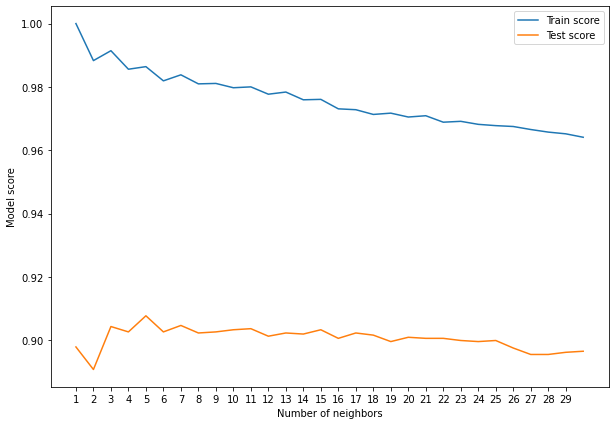

```python
plt.figure(figsize=(10, 7))
plt.plot(neighbors, train_score, label="Train score")
plt.plot(neighbors, test_score, label="Test score")
plt.xticks(np.arange(1, 30, 1))
plt.xlabel("Number of neighbors")
plt.ylabel("Model score")
plt.legend()

print(f"Maximum KNN score on the test data: {max(train_score)*100:.2f}")
```

```python
max_value = max(test_score[0:-2])
max_value
```

```
0.9077027485578555
```

- return the index of the highest value on the list

```python
index_max = test_score.index(max_value)
index_max
```

```
4
```

```python
knn_clf = KNeighborsClassifier(n_neighbors=index_max)
knn_clf.fit(x_train, y_train)

print_score(knn_clf, x_train, y_train, x_test, y_test, train=True)
print_score(knn_clf, x_train, y_train, x_test, y_test, train=False)
```

```
Train Result:
================================================
Accuracy Score: 98.56%
_______________________________________________
CLASSIFICATION REPORT:
                     0            1           2            3       4  \
precision     0.940649     0.993513    1.000000     0.990909     1.0
recall        0.991994     0.999068    0.994929     0.932348     1.0
f1-score      0.965639     0.996283    0.997458     0.960737     1.0
support    1374.000000  1073.000000  986.000000  1286.000000  1407.0

                     5  accuracy    macro avg  weighted avg
precision     0.998369  0.985582     0.987240      0.986099
recall        0.998369  0.985582     0.986118      0.985582
f1-score      0.998369  0.985582     0.986414      0.985555
support    1226.000000  0.985582  7352.000000   7352.000000
_______________________________________________
Confusion Matrix:
 [[1363    0    0   11    0    0]
 [   0 1072    0    0    0    1]
 [   0    4  981    0    0    1]
 [  86    1    0 1199    0    0]
 [   0    0    0    0 1407    0]
 [   0    2    0    0    0 1224]]

Test Result:
================================================
Accuracy Score: 90.26%
_______________________________________________
CLASSIFICATION REPORT:
                    0           1           2           3      4           5  \
precision    0.808241    0.848544    0.940678    0.943734    1.0    0.913295
recall       0.958647    0.927813    0.792857    0.751527    1.0    0.955645
f1-score     0.877042    0.886410    0.860465    0.836735    1.0    0.933990
support    532.000000  471.000000  420.000000  491.000000  537.0  496.000000

           accuracy    macro avg  weighted avg
precision  0.902613     0.909082      0.908755
recall     0.902613     0.897748      0.902613
f1-score   0.902613     0.899107      0.901451
support    0.902613  2947.000000   2947.000000
_______________________________________________
Confusion Matrix:
 [[510   0   0  22   0   0]
 [  0 437   6   0   0  28]
 [  0  70 333   0   0  17]
 [121   1   0 369   0   0]
 [  0   0   0   0 537   0]
 [  0   7  15   0   0 474]]
```

```python
test_score = accuracy_score(y_test, knn_clf.predict(x_test)) * 100
train_score = accuracy_score(y_train, knn_clf.predict(x_train)) * 100

results_df_2 = pd.DataFrame(data=[["K-nearest neighbors", train_score, test_score]],
                          columns=['Model', 'Training Accuracy %', 'Testing Accuracy %'])
tuning_results_df_sf = tuning_results_df_sf.append(results_df_2, ignore_index=True)
tuning_results_df_sf
```

|  | Model | Training Accuracy % | Testing Accuracy % |
| --- | --- | --- | --- |
| 0 | Logistic Regression | 97.238847 | 92.670512 |
| 1 | K-nearest neighbors | 98.558215 | 90.261283 |

### 3. Support Vector Machine

- The support vector machine is created doc: https://scikit-learn.org/stable/modules/generated/sklearn.svm.SVC.html?highlight=svc#sklearn.svm.SVC
- Gridsearch performs the tests for different models.

```python
from sklearn.svm import SVC
from sklearn.model_selection import GridSearchCV

svm_clf = SVC(kernel='rbf', gamma=0.1, C=1.0) #Create instance of the SVC class

params = {"C":(0.1, 0.5, 1, 2, 5, 10, 20),
          "gamma":(0.001, 0.01, 0.1, 0.25, 0.5, 0.75, 1),
          "kernel":('linear', 'poly', 'rbf')} #dict of parameters to try

svm_cv = GridSearchCV(svm_clf, params, n_jobs=-1, cv=5, verbose=1, scoring="accuracy")
svm_cv.fit(x_train, y_train)
best_params = svm_cv.best_params_
print(f"Best params: {best_params}")
```

```
Fitting 5 folds for each of 147 candidates, totalling 735 fits
Best params: {'C': 0.1, 'gamma': 0.1, 'kernel': 'poly'}
```

```python
svm_clf = SVC(**best_params)
svm_clf.fit(x_train, y_train)

print_score(svm_clf, x_train, y_train, x_test, y_test, train=True)
print_score(svm_clf, x_train, y_train, x_test, y_test, train=False)
```

```
Train Result:
================================================
Accuracy Score: 97.88%
_______________________________________________
CLASSIFICATION REPORT:
                     0            1      2            3       4            5  \
precision     0.934426     1.000000    1.0     0.949881     1.0     0.999185
recall        0.954148     0.999068    1.0     0.928460     1.0     1.000000
f1-score      0.944184     0.999534    1.0     0.939048     1.0     0.999592
support    1374.000000  1073.000000  986.0  1286.000000  1407.0  1226.000000

           accuracy    macro avg  weighted avg
precision  0.978781     0.980582      0.978842
recall     0.978781     0.980279      0.978781
f1-score   0.978781     0.980393      0.978771
support    0.978781  7352.000000   7352.000000
_______________________________________________
Confusion Matrix:
 [[1311    0    0   63    0    0]
 [   0 1072    0    0    0    1]
 [   0    0  986    0    0    0]
 [  92    0    0 1194    0    0]
 [   0    0    0    0 1407    0]
 [   0    0    0    0    0 1226]]

Test Result:
================================================
Accuracy Score: 93.69%
_______________________________________________
CLASSIFICATION REPORT:
                    0           1           2           3      4           5  \
precision    0.877586    0.928889    0.982673    0.947964    1.0    0.900749
recall       0.956767    0.887473    0.945238    0.853360    1.0    0.969758
f1-score     0.915468    0.907709    0.963592    0.898178    1.0    0.933981
support    532.000000  471.000000  420.000000  491.000000  537.0  496.000000

           accuracy    macro avg  weighted avg
precision  0.936885     0.939644      0.938693
recall     0.936885     0.935433      0.936885
f1-score   0.936885     0.936488      0.936725
support    0.936885  2947.000000   2947.000000
_______________________________________________
Confusion Matrix:
 [[509   0   0  23   0   0]
 [  0 418   4   0   0  49]
 [  0  19 397   0   0   4]
 [ 71   1   0 419   0   0]
 [  0   0   0   0 537   0]
 [  0  12   3   0   0 481]]
```

```python
test_score = accuracy_score(y_test, svm_clf.predict(x_test)) * 100
train_score = accuracy_score(y_train, svm_clf.predict(x_train)) * 100

results_df_2 = pd.DataFrame(data=[["Support Vector Machine", train_score, test_score]],
                          columns=['Model', 'Training Accuracy %', 'Testing Accuracy %'])
tuning_results_df_sf = tuning_results_df_sf.append(results_df_2, ignore_index=True)
tuning_results_df_sf
```

|  | Model | Training Accuracy % | Testing Accuracy % |
| --- | --- | --- | --- |
| 0 | Logistic Regression | 97.238847 | 92.670512 |
| 1 | K-nearest neighbors | 98.558215 | 90.261283 |
| 2 | Support Vector Machine | 97.878128 | 93.688497 |

### 4. Decision Tree Classifier

- Now we approach the classification by a decision tree.
- Doc: https://scikit-learn.org/stable/modules/generated/sklearn.tree.DecisionTreeClassifier.html

```python
from sklearn.tree import DecisionTreeClassifier
from sklearn.model_selection import GridSearchCV
```

```python
# We search for the accuracy score according to our database and the parameters we define
# citerion is a function to measure the quality of a split.
#gini impurity measures the frequency at which any element of the dataset will be mislabelled when it is randomly labeled
#Entropy is a measure of information that indicates the disorder of the features with the target
#gini and entropy are quite similair
#splitter is the strategy used to choose the split at each node.

params = {"criterion":("gini", "entropy"),
          "splitter":("best", "random"),
          "max_depth":(list(range(1, 20))),
          "min_samples_split":[2, 3, 4],
          "min_samples_leaf":list(range(1, 20))
          }

tree_clf = DecisionTreeClassifier(random_state= 50)

#n_jobs is the the number of jobs to run in parallel.
tree_cv = GridSearchCV(tree_clf, params, scoring="accuracy", n_jobs=-1, verbose=1, cv=3)
tree_cv.fit(x_train, y_train)
best_params = tree_cv.best_params_
print(f'Best_params: {best_params}')
```

```
Fitting 3 folds for each of 4332 candidates, totalling 12996 fits
Best_params: {'criterion': 'gini', 'max_depth': 6, 'min_samples_leaf': 5, 'min_samples_split': 2, 'splitter': 'random'}
```

```python
tree_clf = DecisionTreeClassifier(**best_params)
tree_clf.fit(x_train, y_train)

print_score(tree_clf, x_train, y_train, x_test, y_test, train=True)
print_score(tree_clf, x_train, y_train, x_test, y_test, train=False)
```

```
Train Result:
================================================
Accuracy Score: 90.06%
_______________________________________________
CLASSIFICATION REPORT:
                     0            1           2            3       4  \
precision     0.913076     0.831512    0.888774     0.875749     1.0
recall        0.879185     0.850885    0.875254     0.909798     1.0
f1-score      0.895810     0.841087    0.881962     0.892449     1.0
support    1374.000000  1073.000000  986.000000  1286.000000  1407.0

                     5  accuracy    macro avg  weighted avg
precision     0.870994  0.900571     0.896684      0.901001
recall        0.864600  0.900571     0.896620      0.900571
f1-score      0.867786  0.900571     0.896516      0.900644
support    1226.000000  0.900571  7352.000000   7352.000000
_______________________________________________
Confusion Matrix:
 [[1208    0    0  166    0    0]
 [   0  913   55    0    0  105]
 [   0   71  863    0    0   52]
 [ 115    0    1 1170    0    0]
 [   0    0    0    0 1407    0]
 [   0  114   52    0    0 1060]]

Test Result:
================================================
Accuracy Score: 83.81%
_______________________________________________
CLASSIFICATION REPORT:
                    0           1           2           3      4           5  \
precision    0.823194    0.844444    0.828042    0.805274    1.0    0.736842
recall       0.813910    0.726115    0.745238    0.808554    1.0    0.903226
f1-score     0.818526    0.780822    0.784461    0.806911    1.0    0.811594
support    532.000000  471.000000  420.000000  491.000000  537.0  496.000000

           accuracy    macro avg  weighted avg
precision   0.83814     0.839633      0.841979
recall      0.83814     0.832840      0.838140
f1-score    0.83814     0.833719      0.837611
support     0.83814  2947.000000   2947.000000
_______________________________________________
Confusion Matrix:
 [[433   3   0  96   0   0]
 [  0 342  27   0   0 102]
 [  0  49 313   0   0  58]
 [ 93   1   0 397   0   0]
 [  0   0   0   0 537   0]
 [  0  10  38   0   0 448]]
```

```python
test_score = accuracy_score(y_test, tree_clf.predict(x_test)) * 100
train_score = accuracy_score(y_train, tree_clf.predict(x_train)) * 100

results_df_2 = pd.DataFrame(data=[["Decision Tree Classifier", train_score, test_score]],
                          columns=['Model', 'Training Accuracy %', 'Testing Accuracy %'])
tuning_results_df_sf = tuning_results_df_sf.append(results_df_2, ignore_index=True)
tuning_results_df_sf
```

|  | Model | Training Accuracy % | Testing Accuracy % |
| --- | --- | --- | --- |
| 0 | Logistic Regression | 97.238847 | 92.670512 |
| 1 | K-nearest neighbors | 98.558215 | 90.261283 |
| 2 | Support Vector Machine | 97.878128 | 93.688497 |
| 3 | Decision Tree Classifier | 90.057127 | 83.814048 |

### 5. Random Forest Classifier

- Random forest algorithm builds a forest in the form of an ensemble of decision trees which adds more randomness while growing the trees.
- While splitting a node, the algorithm searches for the best features from the random subset of features
- Doc: https://scikit-learn.org/stable/modules/generated/sklearn.ensemble.RandomForestClassifier.html?highlight=randomforestclassifier#sklearn.ensemble.RandomForestClassifier

```python
from sklearn.ensemble import RandomForestClassifier
from sklearn.model_selection import RandomizedSearchCV

#max_features is the number of features to consider when looking for the best split
#n estimators is the number of the trees we want to build
n_estimators = [500, 900, 1100, 1500]
max_features = ['auto', None]
max_depth = [2, 3, 5, 10, 15, None]
min_samples_split = [2, 5, 10]
min_samples_leaf = [1, 2, 4]

params_grid = {
    'n_estimators': n_estimators,
    'max_features': max_features,
    'max_depth': max_depth,
    'min_samples_split': min_samples_split,
    'min_samples_leaf': min_samples_leaf
              }

rf_clf = RandomForestClassifier(random_state=32)
rf_cv = GridSearchCV(rf_clf, params_grid, scoring="accuracy", cv=3, verbose=1, n_jobs=-1)
rf_cv.fit(x_train, y_train)
best_params = rf_cv.best_params_
print(f"Best parameters: {best_params}")
```

```
Fitting 3 folds for each of 432 candidates, totalling 1296 fits
Best parameters: {'max_depth': None, 'max_features': 'auto', 'min_samples_leaf': 4, 'min_samples_split': 2, 'n_estimators': 500}
```

```python
rf_clf = RandomForestClassifier(**best_params)
rf_clf.fit(x_train, y_train)

print_score(rf_clf, x_train, y_train, x_test, y_test, train=True)
print_score(rf_clf, x_train, y_train, x_test, y_test, train=False)
```

```
Train Result:
================================================
Accuracy Score: 99.84%
_______________________________________________
CLASSIFICATION REPORT:
                     0       1           2            3       4            5  \
precision     0.994920     1.0    0.998986     0.997660     1.0     0.999184
recall        0.997817     1.0    0.998986     0.994557     1.0     0.999184
f1-score      0.996366     1.0    0.998986     0.996106     1.0     0.999184
support    1374.000000  1073.0  986.000000  1286.000000  1407.0  1226.000000

           accuracy    macro avg  weighted avg
precision  0.998368     0.998458      0.998369
recall     0.998368     0.998424      0.998368
f1-score   0.998368     0.998440      0.998368
support    0.998368  7352.000000   7352.000000
_______________________________________________
Confusion Matrix:
 [[1371    0    0    3    0    0]
 [   0 1073    0    0    0    0]
 [   0    0  985    0    0    1]
 [   7    0    0 1279    0    0]
 [   0    0    0    0 1407    0]
 [   0    0    1    0    0 1225]]

Test Result:
================================================
Accuracy Score: 91.08%
_______________________________________________
CLASSIFICATION REPORT:
                    0           1           2           3      4           5  \
precision    0.883721    0.839286    0.929919    0.918103    1.0    0.896484
recall       0.928571    0.898089    0.821429    0.867617    1.0    0.925403
f1-score     0.905591    0.867692    0.872314    0.892147    1.0    0.910714
support    532.000000  471.000000  420.000000  491.000000  537.0  496.000000

           accuracy    macro avg  weighted avg
precision  0.910757     0.911252      0.912268
recall     0.910757     0.906852      0.910757
f1-score   0.910757     0.908076      0.910617
support    0.910757  2947.000000   2947.000000
_______________________________________________
Confusion Matrix:
 [[494   0   0  38   0   0]
 [  0 423  14   0   0  34]
 [  0  56 345   0   0  19]
 [ 65   0   0 426   0   0]
 [  0   0   0   0 537   0]
 [  0  25  12   0   0 459]]
```

```python
test_score = accuracy_score(y_test, rf_clf.predict(x_test)) * 100
train_score = accuracy_score(y_train, rf_clf.predict(x_train)) * 100

results_df_2 = pd.DataFrame(data=[["Random Forest Classifier", train_score, test_score]],
                          columns=['Model', 'Training Accuracy %', 'Testing Accuracy %'])
tuning_results_df_sf = tuning_results_df_sf.append(results_df_2, ignore_index=True)
tuning_results_df_sf
```

|  | Model | Training Accuracy % | Testing Accuracy % |
| --- | --- | --- | --- |
| 0 | Logistic Regression | 97.238847 | 92.670512 |
| 1 | K-nearest neighbors | 98.558215 | 90.261283 |
| 2 | Support Vector Machine | 97.878128 | 93.688497 |
| 3 | Decision Tree Classifier | 90.057127 | 83.814048 |
| 4 | Random Forest Classifier | 99.836779 | 91.075670 |

### 6. XGBoost Classifier Hyperparameter Tuning

- The eXtreme Gradiant Boosting classifier is implemented instead of using sklern's version. Doc: https://xgboost.readthedocs.io/en/stable/
- Given that the hyperparameters can be lists of numbers, it is better to perform a randomized search for imperparameters. With this, not all parameters will be tried but a random selection of parameters given a probability function to search in each parameter. Computation time is then more efficient. https://scikit-learn.org/stable/modules/generated/sklearn.model_selection.RandomizedSearchCV.html#sklearn.model_selection.RandomizedSearchCV

```python
from xgboost import XGBClassifier
from sklearn.model_selection import RandomizedSearchCV

param_grid = dict(
    n_estimators=stats.randint(10, 1000),
    max_depth=stats.randint(1, 10),
    learning_rate=stats.uniform(0, 1)
)

xgb_clf = XGBClassifier()


xgb_cv = RandomizedSearchCV(
    xgb_clf, param_grid, cv=3, n_iter=50,
    scoring='accuracy', n_jobs=-1, verbose=1
)
xgb_cv.fit(x_train, y_train)
best_params = xgb_cv.best_params_
print(f"Best paramters: {best_params}")
```

```
Fitting 3 folds for each of 50 candidates, totalling 150 fits
Best paramters: {'learning_rate': 0.653614986830765, 'max_depth': 1, 'n_estimators': 187}
```

```python
xgb_clf = XGBClassifier(**best_params)
xgb_clf.fit(x_train, y_train)

print_score(xgb_clf, x_train, y_train, x_test, y_test, train=True)
print_score(xgb_clf, x_train, y_train, x_test, y_test, train=False)
```

```
Train Result:
================================================
Accuracy Score: 99.92%
_______________________________________________
CLASSIFICATION REPORT:
                     0       1      2            3       4       5  accuracy  \
precision     0.997817     1.0    1.0     0.997667     1.0     1.0  0.999184
recall        0.997817     1.0    1.0     0.997667     1.0     1.0  0.999184
f1-score      0.997817     1.0    1.0     0.997667     1.0     1.0  0.999184
support    1374.000000  1073.0  986.0  1286.000000  1407.0  1226.0  0.999184

             macro avg  weighted avg
precision     0.999247      0.999184
recall        0.999247      0.999184
f1-score      0.999247      0.999184
support    7352.000000   7352.000000
_______________________________________________
Confusion Matrix:
 [[1371    0    0    3    0    0]
 [   0 1073    0    0    0    0]
 [   0    0  986    0    0    0]
 [   3    0    0 1283    0    0]
 [   0    0    0    0 1407    0]
 [   0    0    0    0    0 1226]]

Test Result:
================================================
Accuracy Score: 92.03%
_______________________________________________
CLASSIFICATION REPORT:
                    0           1           2           3      4           5  \
precision    0.892086    0.888889    0.942065    0.922581    1.0    0.878049
recall       0.932331    0.866242    0.890476    0.873727    1.0    0.943548
f1-score     0.911765    0.877419    0.915545    0.897490    1.0    0.909621
support    532.000000  471.000000  420.000000  491.000000  537.0  496.000000

           accuracy    macro avg  weighted avg
precision  0.920258     0.920612      0.921080
recall     0.920258     0.917721      0.920258
f1-score   0.920258     0.918640      0.920153
support    0.920258  2947.000000   2947.000000
_______________________________________________
Confusion Matrix:
 [[496   1   0  35   0   0]
 [  0 408  13   1   0  49]
 [  0  30 374   0   0  16]
 [ 60   2   0 429   0   0]
 [  0   0   0   0 537   0]
 [  0  18  10   0   0 468]]
```

```python
test_score = accuracy_score(y_test, xgb_clf.predict(x_test)) * 100
train_score = accuracy_score(y_train, xgb_clf.predict(x_train)) * 100

results_df_2 = pd.DataFrame(data=[["XGBoost Classifier", train_score, test_score]],
                          columns=['Model', 'Training Accuracy %', 'Testing Accuracy %'])
tuning_results_df_sf = tuning_results_df_sf.append(results_df_2, ignore_index=True)
tuning_results_df_sf
```

|  | Model | Training Accuracy % | Testing Accuracy % |
| --- | --- | --- | --- |
| 0 | Logistic Regression | 97.238847 | 92.670512 |
| 1 | K-nearest neighbors | 98.558215 | 90.261283 |
| 2 | Support Vector Machine | 97.878128 | 93.688497 |
| 3 | Decision Tree Classifier | 90.057127 | 83.814048 |
| 4 | Random Forest Classifier | 99.836779 | 91.075670 |
| 5 | XGBoost Classifier | 99.918390 | 92.025789 |